# Preprocessing of Predictor Variables

Frank Fichtenmueller

29 October 2016

Preprocessing the predictor variables

Preprocessint becomes especially necessary and impactfull when using model based approaches, instead of non-parametric, linear Models like regression.

Setting up the test dataset for this exercise

```r
library(caret); library(kernlab); data(spam)
inTrain <-createDataPartition(y=spam$type, p=0.75, list=FALSE)
trn_mail <- spam[inTrain, ]
test_mail <- spam[-inTrain, ]
```

Lets first look at the density parameters for the dataset (variable = Runlength of capital letters in a row in an email)

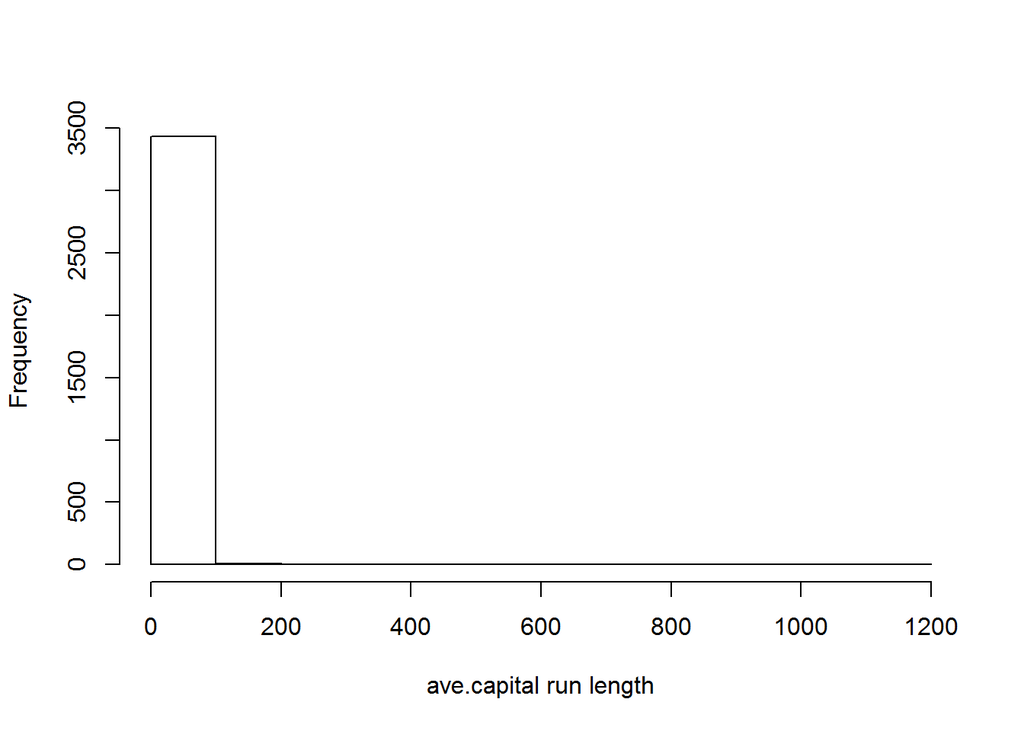

```r
hist(trn_mail$capitalAve, main="", xlab="ave.capital run length")
```

This variable is very skewed and therefore the model approaches will be strongly biased towards the outlying values

```r
mean(trn_mail$capitalAve)
```

```
## [1] 5.673722
```

```r
sd(trn_mail$capitalAve)
```

```
## [1] 36.12904
```

We can standardize the values by subtracting their mean and dividing them by their sd

```r
trainCapAve <- trn_mail$capitalAve
trainCapAveS <- (trainCapAve - mean(trainCapAve))/ sd(trainCapAve)
mean(trainCapAveS)
```

```
## [1] 1.155432e-17
```

```r
sd(trainCapAveS)
```

```
## [1] 1
```

This is essentially the same procedure used in statistics to standardize PDFs in order to translate them into each other, called z-transformation

To avoid leakage of information from the test to the training set, we have to be strongly aware of the fact to never refer to the density parameters of the testset when training our models. This will mean, that we will not get exactly mean=0 and sd=1 in the testset  
when applying the final model. To ilustrate the difference:

```r
testCapAve <- test_mail$capitalAve
testCapAve <- (testCapAve - mean(trainCapAve))/ sd(trainCapAve)
mean(testCapAve)
```

```
## [1] -0.0533988
```

```r
sd(testCapAve)
```

```
## [1] 0.288193
```

To facilitate this process we can use the ‘preProcess()’ function from the ‘caret’ package. The two arguments passed (‘center’, ‘scale’) describe the preprocessing pipeline. We first center the data (subtract mean) and then scale (divide by sd) to get the same result as above

```r
preObj <- preProcess(trn_mail[,-58], method=c("center", "scale"))
trainCapAveS <- predict(preObj, trn_mail[,-58])$capitalAve
mean(trainCapAveS)
```

```
## [1] 1.155432e-17
```

```r
sd(trainCapAveS)
```

```
## [1] 1
```

The resulting object that got returned by the preProcess() can be used to transform the testset via the “predict” attribute.

```r
testCapAveS <- predict(preObj, test_mail[,-58])$capitalAve
mean(testCapAveS)
```

```
## [1] -0.0533988
```

```r
sd(testCapAveS)
```

```
## [1] 0.288193
```

We can also directly pass the preProcessing function as an argument to the train function in caret

```r
set.seed(23456)
modelFit <- train(type ~., data=trn_mail,
                  preProcess=c("center","scale"), method="glm")
```

[output not shown]

```r
modelFit
```

```
## Generalized Linear Model
##
## 3451 samples
##   57 predictor
##    2 classes: 'nonspam', 'spam'
##
## Pre-processing: centered (57), scaled (57)
## Resampling: Bootstrapped (25 reps)
## Summary of sample sizes: 3451, 3451, 3451, 3451, 3451, 3451, ...
## Resampling results:
##
##   Accuracy   Kappa
##   0.9203899  0.8331828
##
##
```

Other kind of transformations to be used Box-Cox transforms

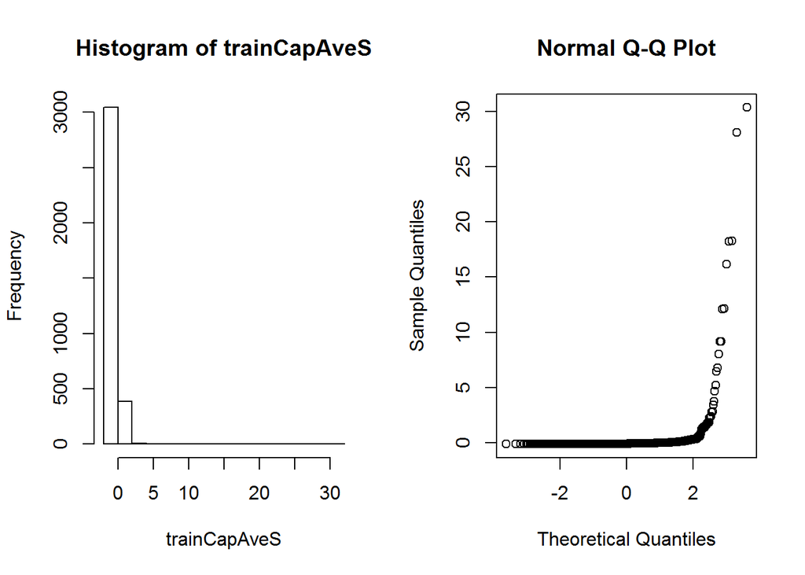

```r
preObj <- preProcess(trn_mail[,-58], method=c('BoxCox'))
tainCapAveS <- predict(preObj, trn_mail[,-58])$capitalAve
par(mfrow=c(1,2)); hist(trainCapAveS); qqnorm(trainCapAveS)
```

Imputing Missing Data as part of the Standardization. One problem can result from missing data, which we have to impute before training the models. Model based approaches in ML are often built not to handle missing Data, as the information included in the dataset is to be followed closely.

We can impute the data using k-nearest neighbors imputation.

```r
set.seed(35467)

#Create some missing values in the dataset
trn_mail$capAve <- trn_mail$capitalAve
selectNa <- rbinom(dim(trn_mail)[1],size=1,prob=0.05)==1
trn_mail$capAve[selectNa] <- NA

#Impute and standardize
preObj <- preProcess(trn_mail[,-58], method='knnImpute')
capAve <- predict(preObj, trn_mail[,-58])$capAve

#Standardize the true values
capAveTruth <- trn_mail$capitalAve
capAveTruth <- (capAveTruth - mean(capAveTruth)/sd(capAveTruth))
```

```r
quantile(capAve - capAveTruth)
```

```
##            0%           25%           50%           75%          100%
## -1072.7245870    -3.6050824    -2.1976478    -1.5345530    -0.9371462
```

Looking closer at only the imputed values, the same result prevails.

```r
quantile((capAve - capAveTruth)[selectNa])
```

```
##          0%         25%         50%         75%        100%
## -60.8406030  -2.9940291  -2.0300415  -1.3866449  -0.9371462
```

```r
quantile((capAve - capAveTruth)[!selectNa])
```

```
##            0%           25%           50%           75%          100%
## -1072.7245870    -3.6357317    -2.2151617    -1.5399044    -0.9726494
```